# IODS course project

Julia ROQUIGNY

install.packages(“usethis”)

usethis::create_github_token()

gitcreds::gitcreds_set()

# Introduction to Open Data Science - Course Project

# About the project

I am a phD student working on rare kidney diseases and immunology. I have followed some specific R courses rather for medical studies which allowed to apply the newly learned R functions for my research work. I would like to broaden my knowledge in the use of R which are not specifically related to my topic. The content of the course looked to me completely new and interesting so I am happy to learn more about open science, open data, data science. I expect to get insight in the coding, the analysis and the interpretation of of regression and model validation, Data wrangling, clustering and classification.

https://github.com/Julia1756/IODS-project.git

```r
# This is a so-called "R chunk" where you can write R code.

date()
```

```
## [1] "Tue Dec 12 17:45:06 2023"
```

Going through R gor health Data science was an insightful learning of R basics and its different functionalities.The content is very didactive. My favorite part was the R basics because I never had the opportunity to take time for learning the basics in depth. I also liked the part allowing to plot different kind of graphs. The most difficult part might be “summarizing data”.

# Chapter 2

# Chapter 2: Regression and model validation

```r
#1 reading the data
student2014 <- read.csv("data/learning2014.csv",header = TRUE,sep=",")

#1 explore the dimension of the data
dim(data)
```

[output not shown]

```r
#1 explore the structure of the data
str(data)
```

```
## function (..., list = character(), package = NULL, lib.loc = NULL, verbose = getOption("verbose"),
##     envir = .GlobalEnv, overwrite = TRUE)
```

The data consist of 166 observations of 7 variables. The variable “gender” is in character formats. The variables “Age”, “Attitude”,“Points” are in integer formats. The variables “deep”, “stra” and “surf” are in numerical formats. The variables, “gender” and “age” give basic information about the different individuals.The variable “attitude” tells us about the attitude of the studied individuals. The variables “deep”, “stra” and “surf” indicates whether the individual relied on deep, surface and strategic learning. The variable “points” corresponds to the points a person got a statistics course exam

install.packages(“GGally”) install.packages(“ggplot2”)

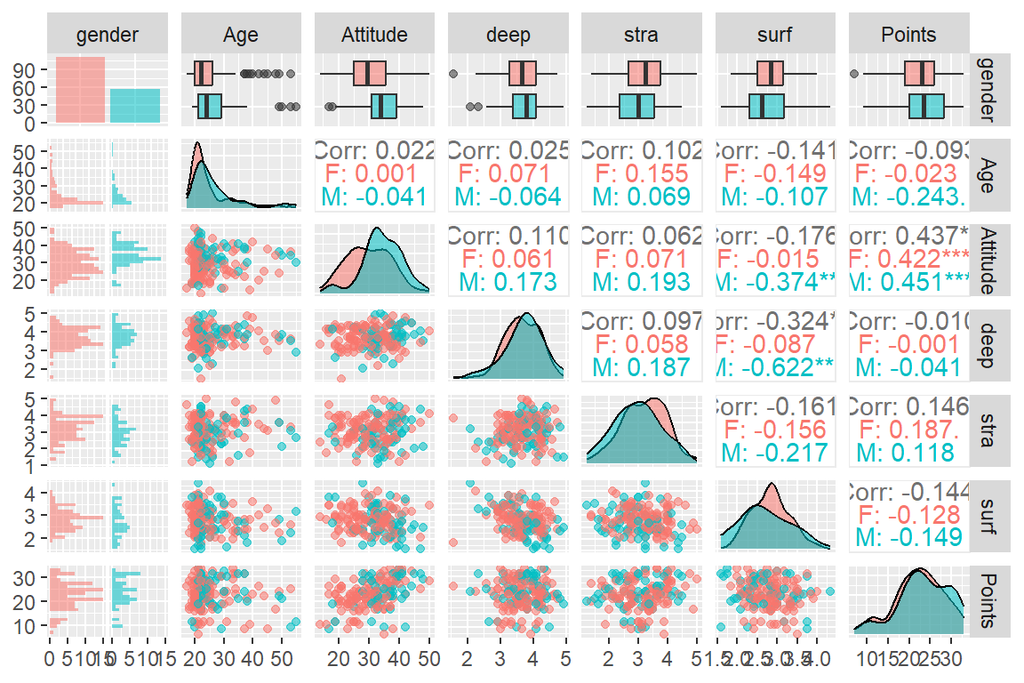

```r
#2  create a plot matrix after install.packages("GGally"), install.packages("ggplot2")

library(ggplot2)
library(GGally)
ggpairs(student2014, mapping = aes(col = gender, alpha = 0.3), lower = list(combo = wrap("facethist", bins = 20)))
```

```r
#2  summary of the fitted model
summary(student2014)
```

```
##     gender               Age           Attitude          deep
##  Length:166         Min.   :17.00   Min.   :14.00   Min.   :1.583
##  Class :character   1st Qu.:21.00   1st Qu.:26.00   1st Qu.:3.333
##  Mode  :character   Median :22.00   Median :32.00   Median :3.667
##                     Mean   :25.51   Mean   :31.43   Mean   :3.680
##                     3rd Qu.:27.00   3rd Qu.:37.00   3rd Qu.:4.083
##                     Max.   :55.00   Max.   :50.00   Max.   :4.917
##       stra            surf           Points
##  Min.   :1.250   Min.   :1.583   Min.   : 7.00
##  1st Qu.:2.625   1st Qu.:2.417   1st Qu.:19.00
##  Median :3.188   Median :2.833   Median :23.00
##  Mean   :3.121   Mean   :2.787   Mean   :22.72
##  3rd Qu.:3.625   3rd Qu.:3.167   3rd Qu.:27.75
##  Max.   :5.000   Max.   :4.333   Max.   :33.00
```